# PhySciM200 problem set 2

Kevin Neal

April 26, 2015

### Questions from Drummond and Tom (2011):

1. Calculate the p-value of finding the observed difference between two samples by doing resampling; if p-value > 0.05, no significant difference can be claimed
2. Larger sample means a better representation of the population and will reduce uncertainty (smaller confidence interval); noise/scatter increases uncertainty by increasing likelihood of different outliers being in different samples and causing their distributions to differ, even if sampled from the same population
3. That there is insufficient evidence of a difference in samples, or that the results are consistent with the null hypothesis. I.e. a lack of evidence is not evidence of absence.
4. No; one can find statistical significance without a significant difference in effect; e.g. two frog samples may be significantly different but the difference in their jump distances may be so small that one could not consistently predict whether a single individual from one population would beat the other.
5. Effect size is the difference in values between two samples. It differs from NHST by putting an actual number on difference, rather than a simple binary statement of significance.

#### Importing and wrangling the data:

```r
dab1raw <- read.csv("Dab1.csv")
head(dab1raw)
```

```
##   animal genotype    box counts
## 1      1       wt Medial    2.0
## 2      2       wt Medial    3.2
## 3      3       wt Medial    3.2
## 4      4       wt Medial    3.9
## 5      5       wt Medial    5.2
## 6      6       wt Medial    4.1
```

```r
str(dab1raw) # genotype and box already read as factors, but in case they weren't:
```

```
## 'data.frame':    200 obs. of  4 variables:
##  $ animal  : int  1 2 3 4 5 6 7 8 9 10 ...
##  $ genotype: Factor w/ 2 levels "scm","wt": 2 2 2 2 2 2 2 2 2 2 ...
##  $ box     : Factor w/ 2 levels "Lateral","Medial": 2 2 2 2 2 2 2 2 2 2 ...
##  $ counts  : num  2 3.2 3.2 3.9 5.2 4.1 3.4 4.1 3.7 3.9 ...
```

```r
# dab1raw$genotype <- with(dab1raw, factor(genotype, levels = c("wt", "scm")))
# dab1raw$box <- with(dab1raw, factor(box, levels = c("medial", "Lateral")))

# use tidyr to cast data based on factors; acast makes array; dcast makes dataframe
castdab <- acast(dab1raw, animal~genotype+box, value.var="counts")
```

#### Bootstrapping median and lateral counts for each genotype:

```r
# bootstrap all columns of data: scm_Lateral, scm_Medial, wt_Lateral, wt_Medial

# get medians of 10000 bootstrap-resampled datasets
castdab.booted <- apply(castdab, 2, FUN = booter, stat = median) # in apply(), the 2 refers to applying over columns (1 for rows)
```

```
## median of 10000 bootstrapped function (x, na.rm = FALSE) UseMethod("median")s, with 95% CI: 6.5 (6, 6.8)
## median of 10000 bootstrapped function (x, na.rm = FALSE) UseMethod("median")s, with 95% CI: 4.9 (4.6, 5.4)
## median of 10000 bootstrapped function (x, na.rm = FALSE) UseMethod("median")s, with 95% CI: 5.6 (5.1, 5.95)
## median of 10000 bootstrapped function (x, na.rm = FALSE) UseMethod("median")s, with 95% CI: 5.2 (5.1, 5.65)
```

```r
castdab.bmean <- apply(castdab, 2, FUN = booter, stat = mean) #  apply() lets you bootstrap all the columns at once
```

```
## median of 10000 bootstrapped function (x, ...) UseMethod("mean")s, with 95% CI: 6.306 (5.728, 6.912)
## median of 10000 bootstrapped function (x, ...) UseMethod("mean")s, with 95% CI: 4.884 (4.388, 5.372)
## median of 10000 bootstrapped function (x, ...) UseMethod("mean")s, with 95% CI: 5.678 (5.048, 6.32)
## median of 10000 bootstrapped function (x, ...) UseMethod("mean")s, with 95% CI: 5.338 (4.938, 5.75)
```

```r
castdab.booted.dims <- dim(castdab.booted)
castdab.madams <- apply(castdab, 2, FUN = booter, stat = madam)
```

```
## median of 10000 bootstrapped function (data, stat = "median") {    stat <- if (!is.null(stat)) {        match.fun(stat)    }    md <- abs(data - median(data))    return(stat(md))}s, with 95% CI: 1.55 (0.95, 2.45)
## median of 10000 bootstrapped function (data, stat = "median") {    stat <- if (!is.null(stat)) {        match.fun(stat)    }    md <- abs(data - median(data))    return(stat(md))}s, with 95% CI: 1.5 (0.65, 2.05)
## median of 10000 bootstrapped function (data, stat = "median") {    stat <- if (!is.null(stat)) {        match.fun(stat)    }    md <- abs(data - median(data))    return(stat(md))}s, with 95% CI: 1.9 (1.1, 2.8)
## median of 10000 bootstrapped function (data, stat = "median") {    stat <- if (!is.null(stat)) {        match.fun(stat)    }    md <- abs(data - median(data))    return(stat(md))}s, with 95% CI: 1.1 (0.55, 1.4)
```

```r
# str(rawdat) # shows data type of the columns
# head(castdab[,colnames(castdab)=="wt_Medial"])
# castdab.booted[,"wt_Medial"]

# hist(castdab[,"scm_Lateral"])
# hist(castdab.booted[,"scm_Lateral"])
# hist(castdab.madams[,"scm_Lateral"])

# castdab$scm_Lateral
```

#### Comparing ratio or difference of medial to lateral counts of each genotype to the ratio or difference of them in the other (Two-Box):

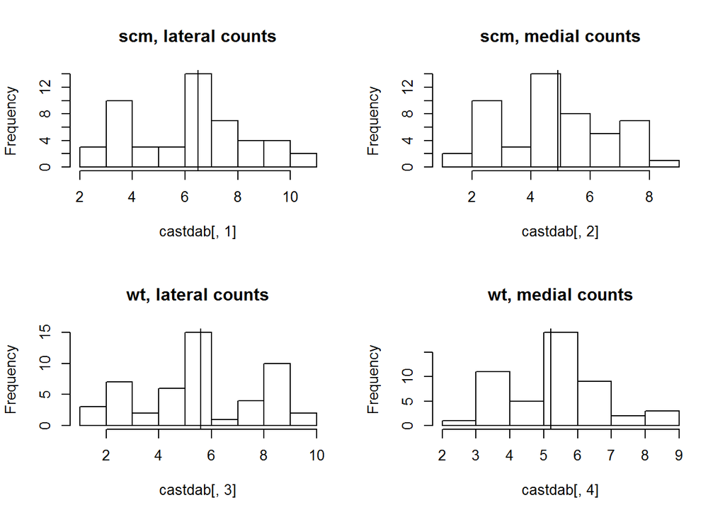

```r
# datA should be the ratio of medial to lateral in scm
# datB should be the ratio of medial to lateral in wt

twobox <- function(datA, datB, reps=10000, stat=median, ratio=T) {
  comparison <- rep(NA, reps)
  if (ratio){
    sclA <- datA / median(datA) # with ratios, does it make more sense to do this by dividing by median, or subtracting median and adding 1?
    sclB <- datB / median(datB)
    for(i in 1:reps){
      bootA <- sample(sclA, length(datA), replace = TRUE)
      bootB <- sample(sclB, length(datB), replace = TRUE)
      comparison[i] <- median(bootA) / median(bootB)
    }
  } else {
      sclA <- datA - median(datA) # don't use scale()
      sclB <- datB - median(datB)
      for(i in 1:reps){
        bootA <- sample(sclA, length(datA), replace = TRUE)
        bootB <- sample(sclB, length(datB), replace = TRUE)
        comparison[i] <- median(bootA) - median(bootB)
      }
    }
  invisible(comparison)
}
# colnames(castdab)
# hist(castdab)
par(mfrow=c(2,2))
hist(castdab[,1], main="scm, lateral counts")
abline(v=median(castdab[,1]))
hist(castdab[,2], main="scm, medial counts")
abline(v=median(castdab[,2]))
hist(castdab[,3], main="wt, lateral counts")
abline(v=median(castdab[,3]))
hist(castdab[,4], main="wt, medial counts")
abline(v=median(castdab[,4]))
```

```r
par(mfrow=c(1,1))

scmRatio <- castdab[,"scm_Medial"] / castdab[,"scm_Lateral"]
scmDiff <- castdab[,"scm_Medial"] - castdab[,"scm_Lateral"]
wtRatio <- castdab[,"wt_Medial"] / castdab[,"wt_Lateral"]
wtDiff <- castdab[,"wt_Medial"] - castdab[,"wt_Lateral"]
```

#### Histograms of ratios of medial to lateral in both genotypes:

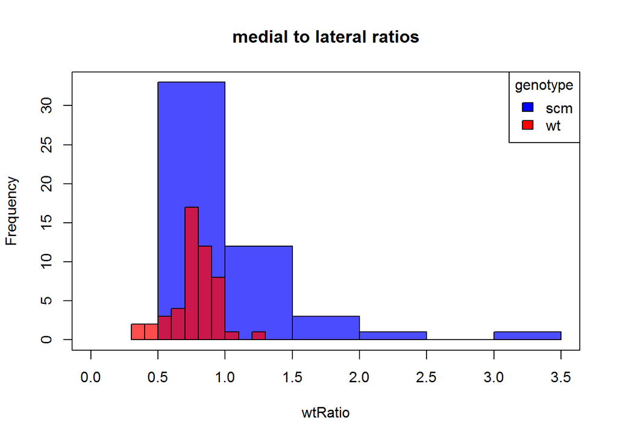

```r
hist(wtRatio, col=rgb(0, 0, 1, 0.7), xlim=c(0,3.5), main="medial to lateral ratios")
hist(scmRatio, col=rgb(1, 0, 0, 0.7), add=T)
legend("topright", title="genotype", legend=c("scm", "wt"), fill=c("blue", "red"))
box()
```

#### Histograms of differences of medial to lateral in both genotypes:

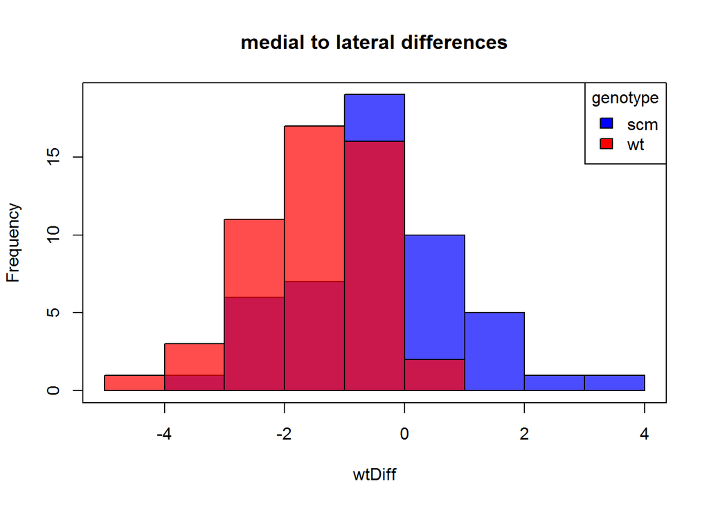

```r
hist(wtDiff, col=rgb(0, 0, 1, 0.7), xlim=c(-5,4), main="medial to lateral differences")
hist(scmDiff, col=rgb(1, 0, 0, 0.7), add=T)
legend("topright", title="genotype", legend=c("scm", "wt"), fill=c("blue", "red"))
box()
```

#### Running two-box comparison

```r
# segments(x0=sort(scmRatio)[0.025*length(scmRatio)], y0=0, y1=30, lwd=2)
# segments(x0=sort(scmRatio)[0.975*length(scmRatio)], y0=0, y1=30, lwd=2)


compareRatioRatio <-  twobox(scmRatio, wtRatio)
compareRatioDiff <- twobox(scmRatio, wtRatio, ratio=F)
compareDiffRatio <- twobox(scmDiff, wtDiff)
compareDiffDiff <- twobox(scmDiff, wtDiff, ratio=F)

# par(mfrow=c(2,2))
# hist(compareRatioRatio)
# hist(compareRatioDiff)
# hist(compareDiffRatio)
# hist(compareDiffDiff)
# # vioplot(compareRatioRatio)
# # vioplot(compareRatioDiff)
# # vioplot(compareDiffDiff)
# # vioplot(compareDiffRatio)
# par(mfrow=c(1,1))
```

#### Confidence intervals and p-values:

```r
# 95% CI
sortCI <- function(bootstraps, reps=10000) {
  sorted <- sort(bootstraps)
  cat("95% CI of ", deparse(substitute(bootstraps)), ": ", sep="")
  return(c(sorted[0.025*reps], sorted[0.975*reps]))
}

# comparisons <- c(compareRatioRatio, compareRatioDiff, compareDiffRatio, compareDiffDiff)
# comparisons[1]
# for (i in 1:4) {
#   sortCI(comparisons[i])
# }

# in lab 4 Khris shows these should all be significant...
rrCI <- sortCI(compareRatioRatio) # 0.917, 1.052
```

```
## 95% CI of compareRatioRatio:
```

```r
# Does observed ratio of medians lie within this interval?
rrmed <- median(scmRatio) / median(wtRatio) # 0.8459
# for p-value: find proportion of bootstrap values greater than actual difference PLUS prop of values less than negative of actual difference

# must rescale around 1 to be in line with above, if doing ratio comparison...
bootpval.2tail <- function(bootdifs, truedif=NULL, ratio=T){
  if (ratio) {
    if (truedif > 1) {
      pval <- sum(bootdifs > truedif) / length(bootdifs) + sum(bootdifs < 2 - truedif) / length(bootdifs)
    } else {
      pval <- sum(bootdifs > 2 - truedif) / length(bootdifs) + sum(bootdifs < truedif) / length(bootdifs)
    }
  } else {
  pval <- sum(bootdifs > abs(truedif)) / length(bootdifs) + sum(bootdifs < -abs(truedif)) / length(bootdifs)
  }
  cat("p-value: ", pval)
  invisible(pval)
}

# testing internal lines above
# sum(compareRatioDiff > 2 - -0.1433) / length(compareRatioDiff) + sum(compareRatioDiff < -0.1433) / length(compareRatioDiff)
# sum(compareRatioDiff > abs(-0.1433)) / length(compareRatioDiff) + sum(compareRatioDiff < -abs(-0.1433)) / length(compareRatioDiff)


# length(compareRatioRatio[compareRatioRatio > abs(rrmed)])
# sum(compareRatioRatio > abs(rrmed)+1)
# length(compareRatioRatio[compareRatioRatio < -abs(rrmed)])
# sum(compareRatioRatio < -abs(rrmed))
par(mfrow=c(1,1))

rrpval <- bootpval.2tail(compareRatioRatio, truedif=rrmed) # 5e-04
```

```
## p-value:  2e-04
```

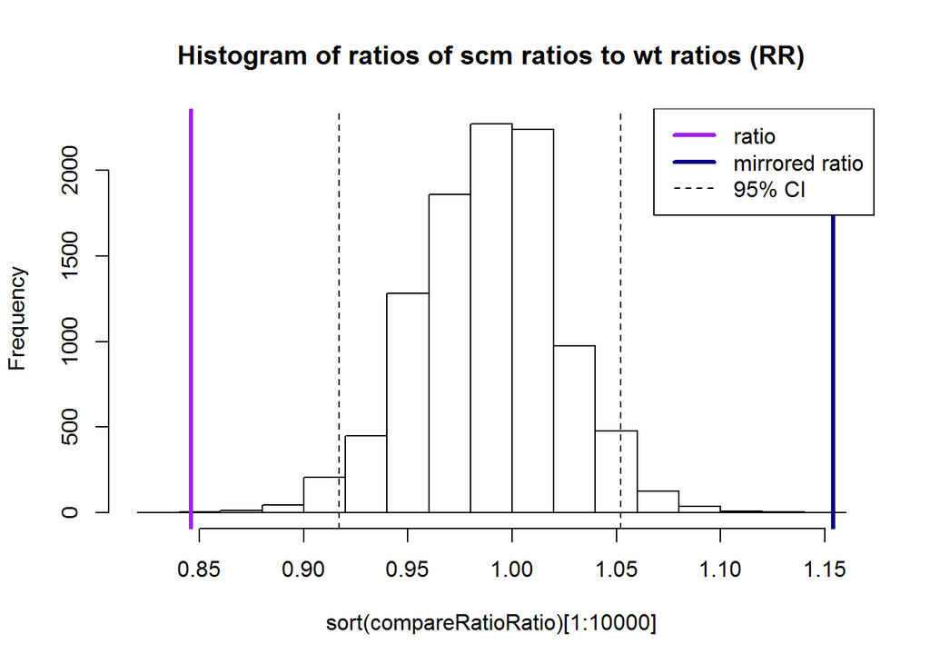

```r
hist(sort(compareRatioRatio)[1:10000], main="Histogram of ratios of scm ratios to wt ratios (RR)", freq=T)
abline(v=rrmed, lwd=3, col="purple") # real ratio
abline(v=2 - rrmed, lwd=3, col="navy") # real ratio mirrored around 1
abline(v=0.917, lty=2) # lower CI
abline(v=1.052, lty=2) # upper CI
legend("topright", legend=c("ratio", "mirrored ratio", "95% CI"), col=c("purple", "navy", "black"),
       lty=c(1,1,2), lwd=c(3,3,1))
```

```r
# segments(x0=sort(compareRatioRatio)[0.025*length(scmRatio)], y0=0, y1=2000, lwd=2)

sortCI(compareRatioDiff) # -0.07543, 0.04182
```

```
## 95% CI of compareRatioDiff:
```

```
## [1] -0.07502352  0.04402963
```

```r
rdmed <- median(scmRatio) - median(wtRatio) # -0.1433
rdpval <- bootpval.2tail(compareRatioDiff, truedif=rdmed, ratio=F) # 0.0005
```

```
## p-value:  2e-04
```

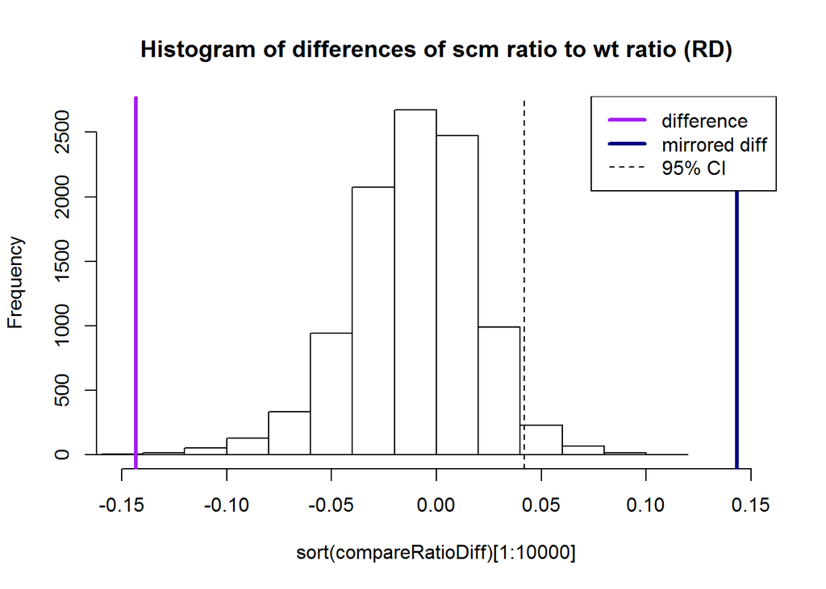

```r
hist(sort(compareRatioDiff)[1:10000], main="Histogram of differences of scm ratio to wt ratio (RD)", xlim=c(-0.15, 0.15))
abline(v=rdmed, lwd=3, col="purple")
abline(v=-rdmed, lwd=3, col="navy")
abline(v=-0.7532, lty=2)
abline(v=0.04182, lty=2)
legend("topright", legend=c("difference", "mirrored diff", "95% CI"), col=c("purple", "navy", "black"),
       lty=c(1,1,2), lwd=c(3,3,1))
```

```r
sortCI(compareDiffRatio) # 0.5, 2.844
```

```
## 95% CI of compareDiffRatio:
```

```
## [1] 0.5155556 3.2000000
```

```r
drmed <- median(scmDiff) / median(wtDiff) # 3.75
drpval <- bootpval.2tail(compareDiffRatio, truedif=drmed) # 0.0308
```

```
## p-value:  0.0318
```

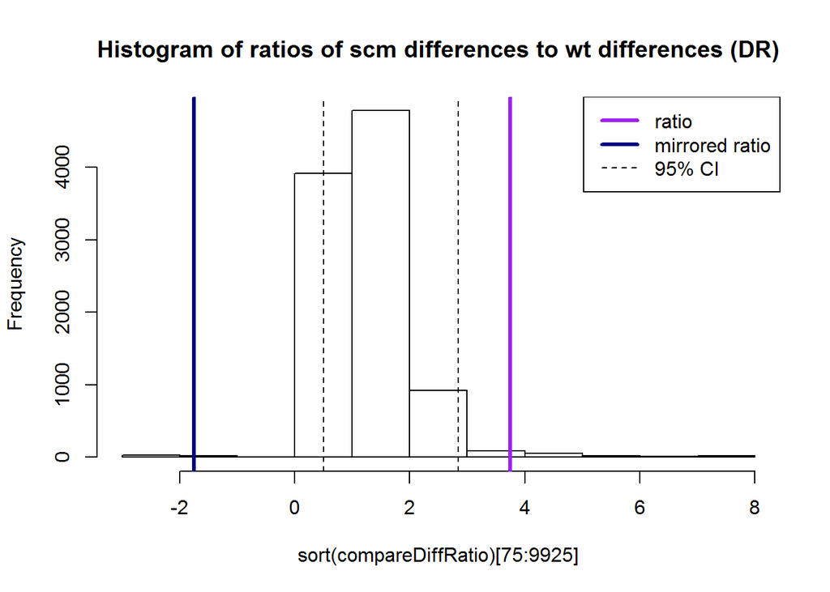

```r
hist(sort(compareDiffRatio)[75:9925], main="Histogram of ratios of scm differences to wt differences (DR)", freq=T)
abline(v=drmed, lwd=3, col="purple")
abline(v=2-drmed, lwd=3, col="navy")
abline(v=0.5, lty=2)
abline(v=2.844, lty=2)
legend("topright", legend=c("ratio", "mirrored ratio", "95% CI"), col=c("purple", "navy", "black"),
       lty=c(1,1,2), lwd=c(3,3,1))
```

```r
sortCI(compareDiffDiff) # -0.45, 0.55
```

```
## 95% CI of compareDiffDiff:
```

```
## [1] -0.45  0.55
```

```r
ddmed <- median(scmDiff) - median(wtDiff)
ddpval <- bootpval.2tail(compareDiffDiff, truedif=ddmed, ratio=F) # 0.0002
```

```
## p-value:  2e-04
```

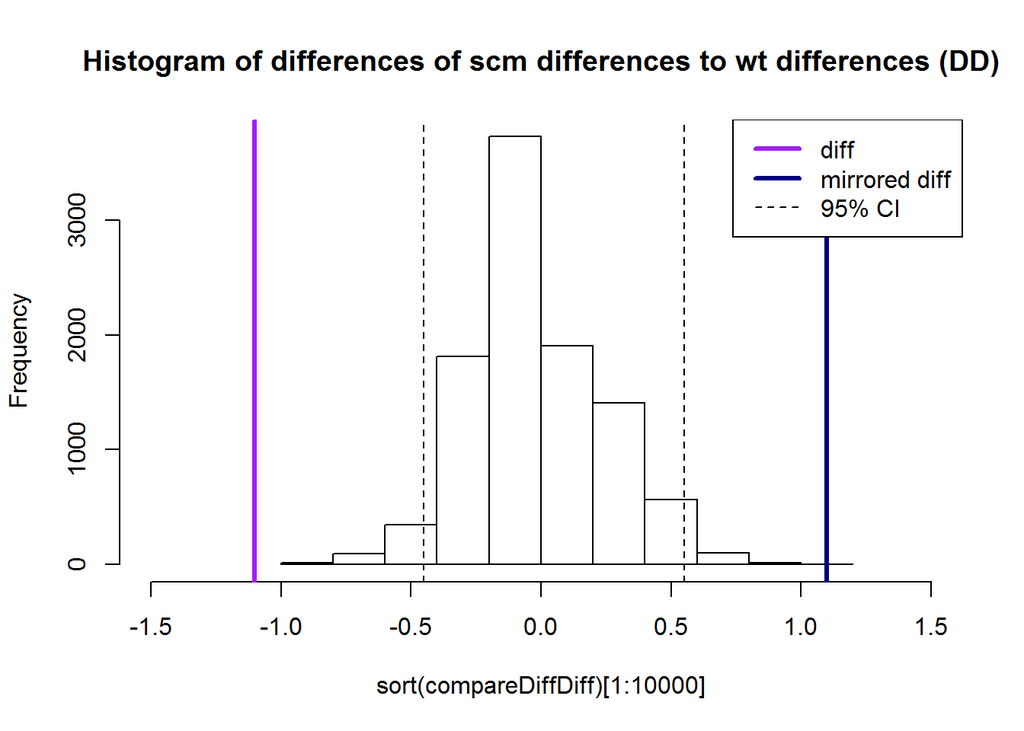

```r
hist(sort(compareDiffDiff)[1:10000], main="Histogram of differences of scm differences to wt differences (DD)", xlim=c(-1.5, 1.5))
abline(v=ddmed, lwd=3, col="purple")
abline(v=-ddmed, lwd=3, col="navy")
abline(v=-0.45, lty=2)
abline(v=0.55, lty=2)
legend("topright", legend=c("diff", "mirrored diff", "95% CI"), col=c("purple", "navy", "black"),
       lty=c(1,1,2), lwd=c(3,3,1))
```

```r
par(mfrow=c(1,1))
```

#### Effect sizes

```r
effsizeboot <- function(datA, datB, reps=10000, stat=median, ratio=T) {
  comparison <- rep(NA, reps)
  if (ratio){
    for(i in 1:reps){
      bootA <- sample(datA, length(datA), replace = TRUE)
      bootB <- sample(datB, length(datB), replace = TRUE)
      comparison[i] <- median(bootA) / median(bootB)
    }
  } else {
      for(i in 1:reps){
        bootA <- sample(datA, length(datA), replace = TRUE)
        bootB <- sample(datB, length(datB), replace = TRUE)
        comparison[i] <- median(bootA) - median(bootB)
      }
    }
  sortmeds <- sort(comparison)
  effectsize <- median(comparison)
  CI <- c(sortmeds[0.025*reps], sortmeds[0.975*reps])
  cat(effectsize, " (", CI[1], ", ", CI[2], ")", sep="")
  invisible(list("effectsize"=effectsize, "CI"=CI))
}

# Zero effect if ratio CI's contain 1; zero effect if difference CI's contain 0
```

```r
rreffectboot <- effsizeboot(scmRatio, wtRatio)
```

```
## 0.8391235 (0.7756968, 0.8916358)
```

```r
rdeffectboot <- effsizeboot(scmRatio, wtRatio, ratio=F)
```

```
## -0.1511479 (-0.2179848, -0.0995566)
```

```r
dreffectboot <- effsizeboot(scmDiff, wtDiff)
```

```
## 4 (1.6875, 10.66667)
```

```r
ddeffectboot <- effsizeboot(scmDiff, wtDiff, ratio=F)
```

```
## -1.15 (-1.55, -0.55)
```

**Effects present in all comparisons**  
* For ratios: if distribution includes 1: zero effect * For differences: if distribution includes 0: zero effect